# One Year (+3 Months) of Us <3

### Hello my love!

I wanted to make some special for you for our anniversary, but ran into the problem of not being able to make anything physical that would capture all of my feelings for you because we are studying abroad and can’t really take a lot of stuff with us and printing costs for all of these images would be rather high. So I found a solution: a website! I always like showing you the data I’ve collected on our relationship, and I think it would be fun to have a bunch of it all in one place, so I’ve created a few visualizations for everything. So here’s a description of each of the tabs, so you can decide what you want to look at.

### Calendars:

I figured out how to make calendars and I wanted to highlight a lot of the special dates in our relationship, like the dates when we went on dates or the ones when I visited you during study abroad.

### Dates:

Here I’ve written a little description for each of the dates we’ve been on based on what I remember from it and why it was important to me.

### Graphs:

Here are all the graphs that I made! These are random things like how many dates we went on per month, which locations they were in, and the date score graph.

### Maps:

Here are maps of each region of the world that we’ve gone on dates in. These are interactable and you can zoom in and out and hover over the little date icons.

I hope you like this :) I love you so so much

## Calendars

Our special days together :)

### The Beginning

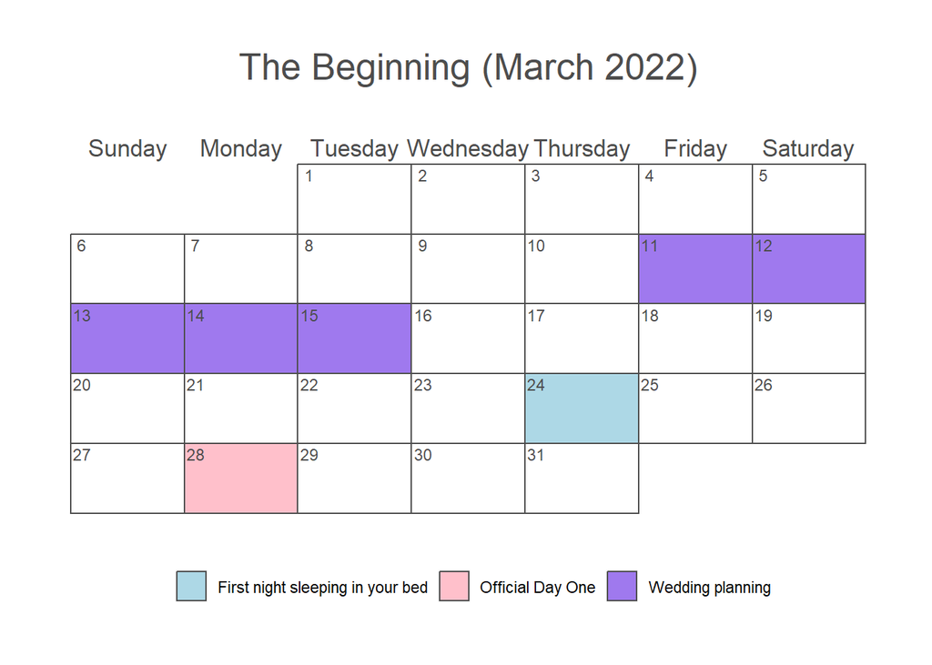

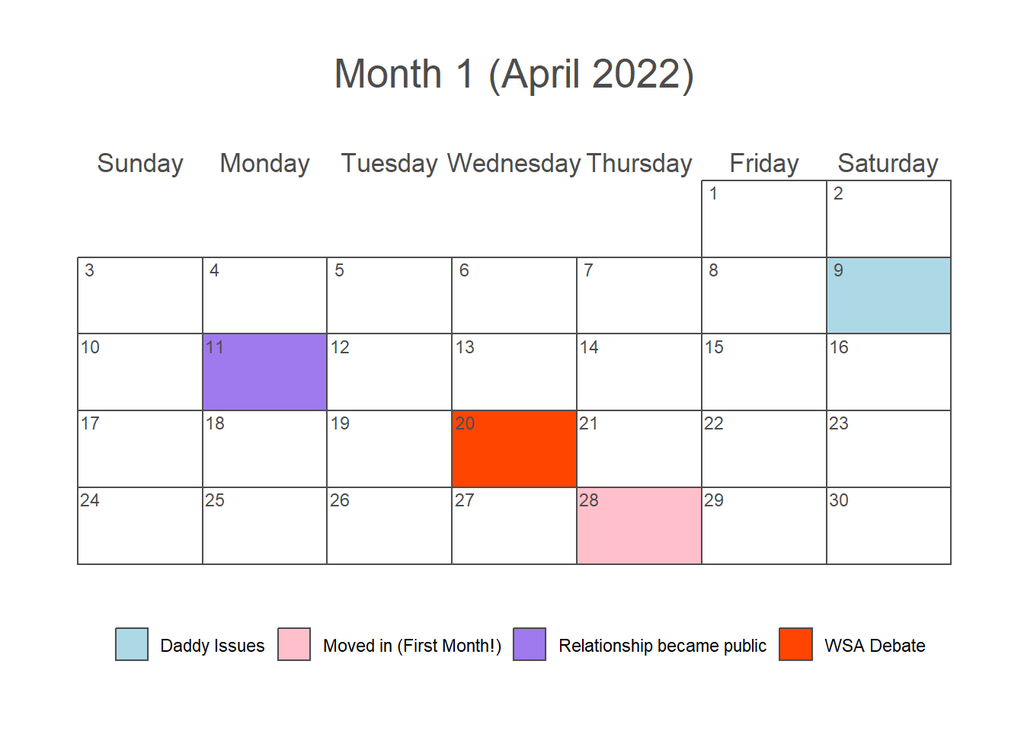

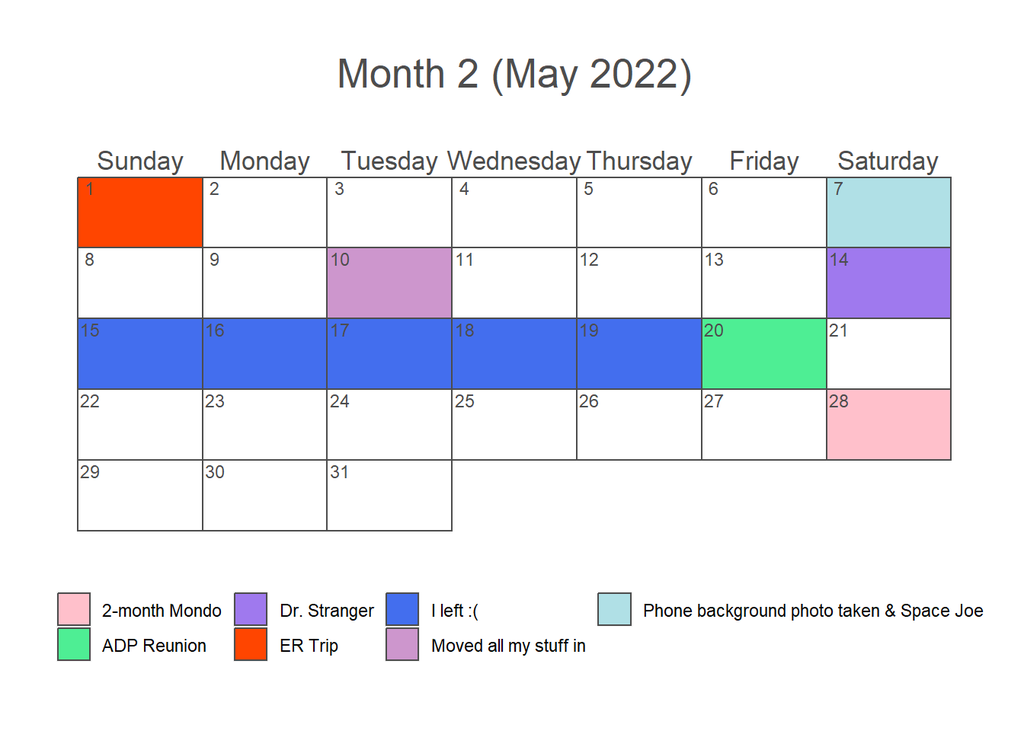

### Our First Summer!

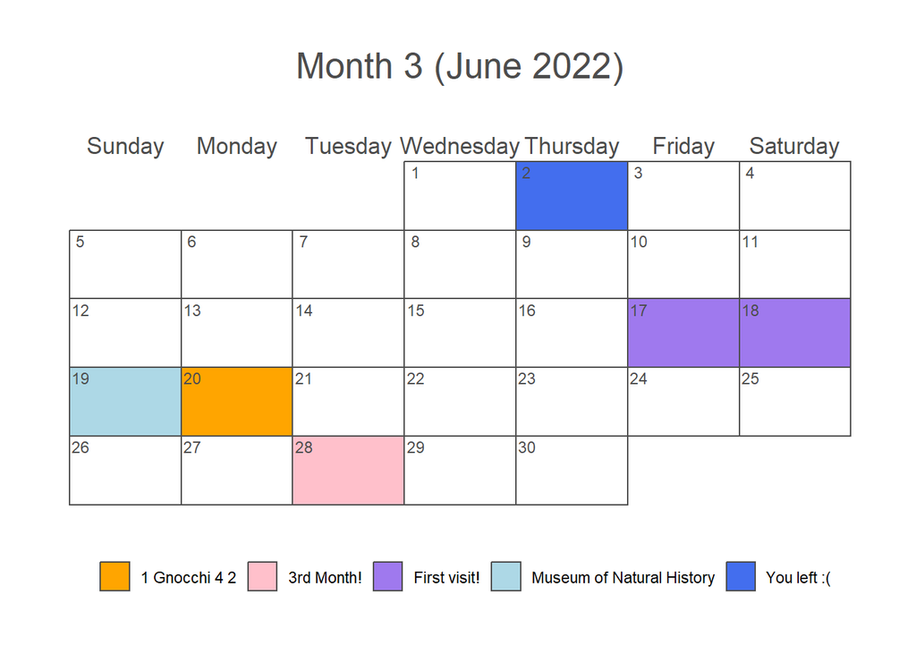

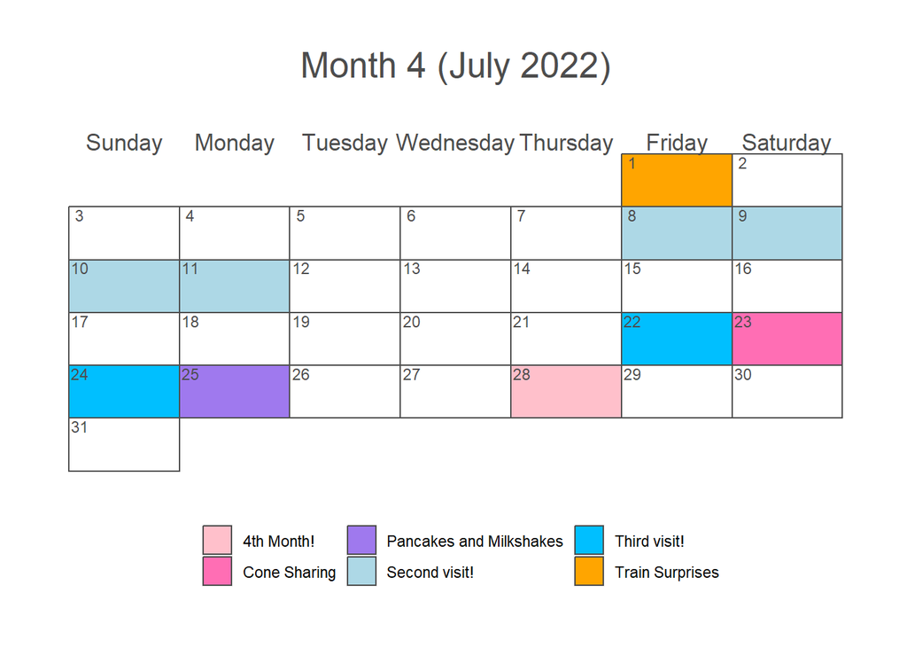

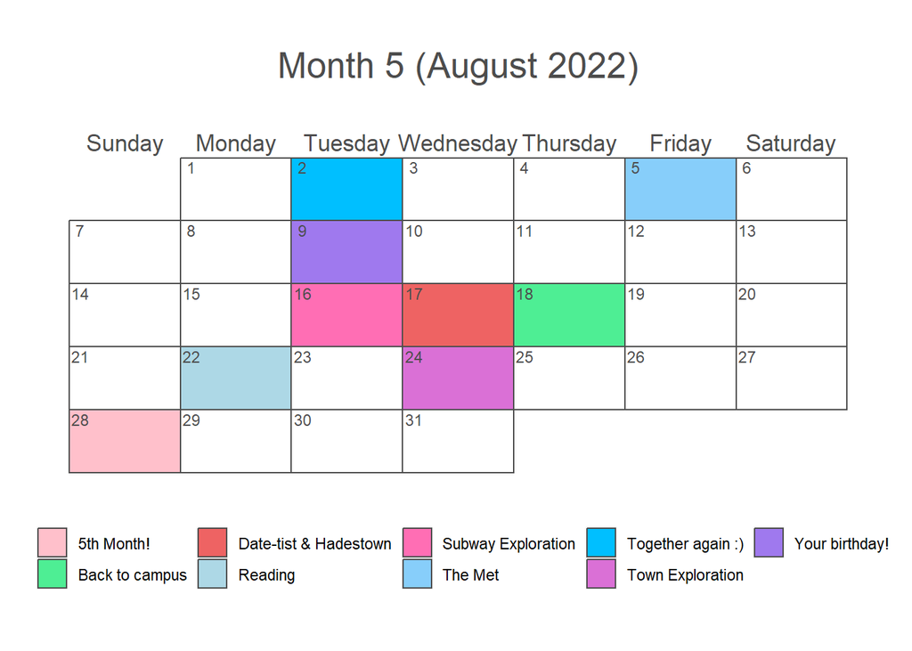

### Our First Fall!

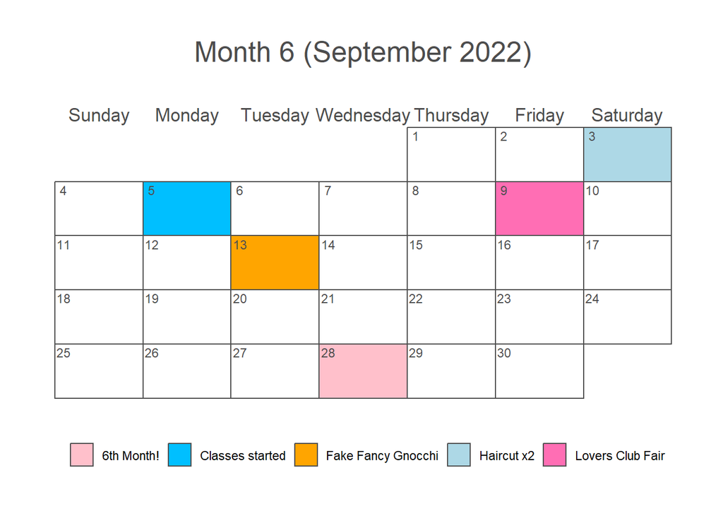

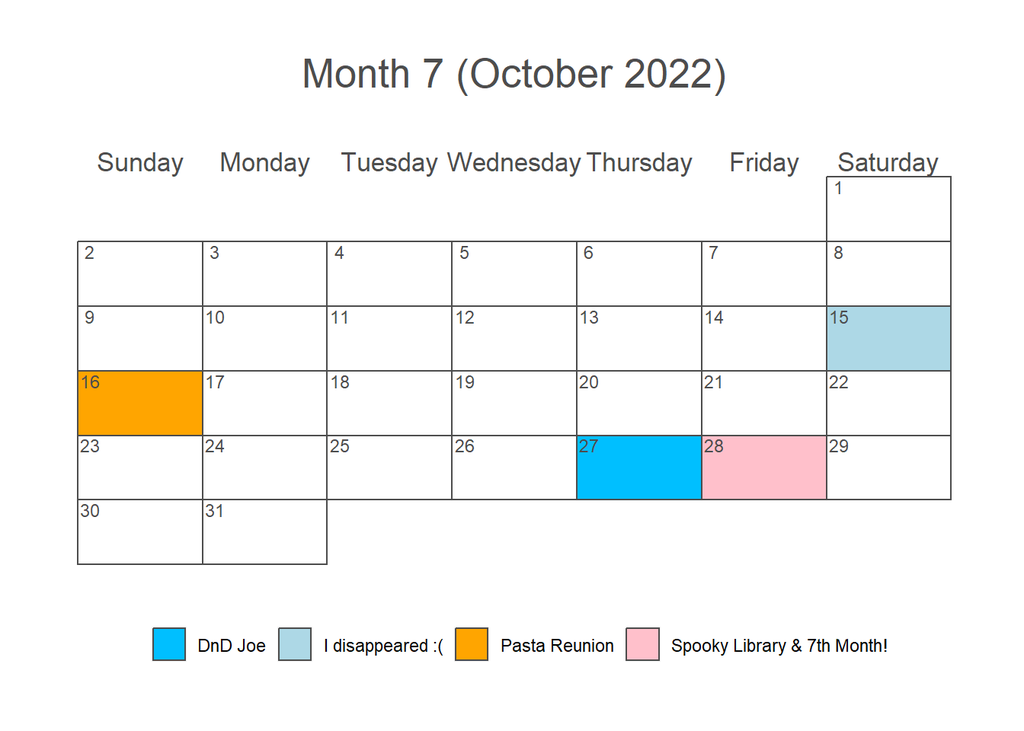

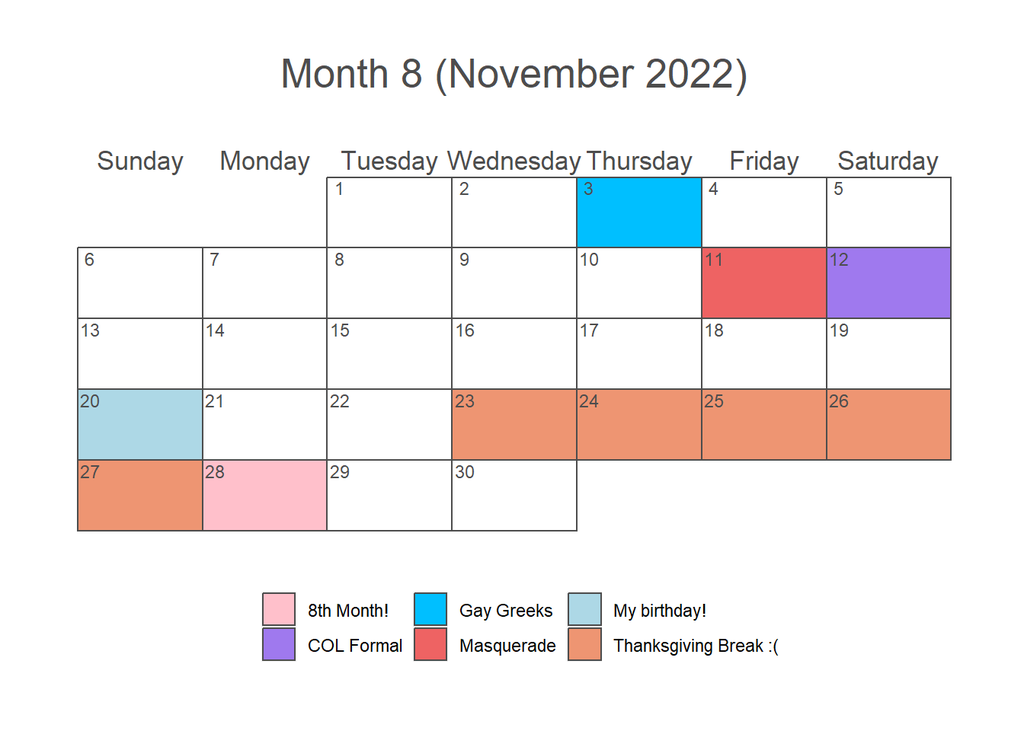

### Winter (ft. the Beginning of Study Abroad)

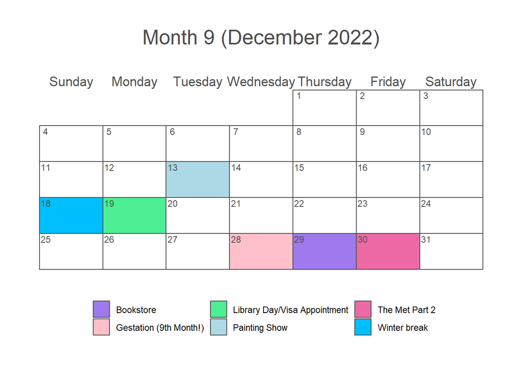

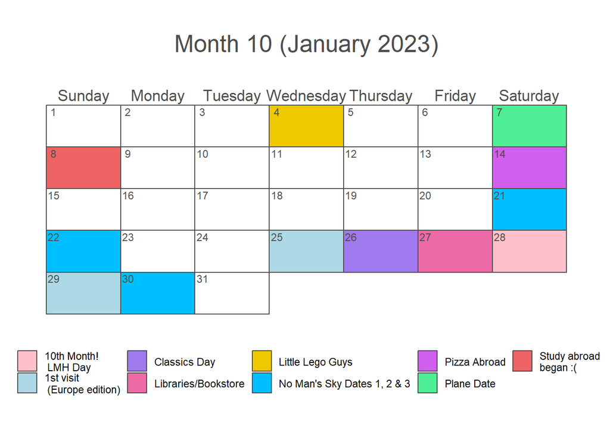

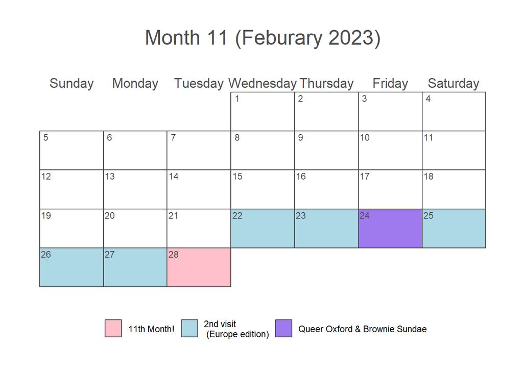

### Study Abroad Part Two

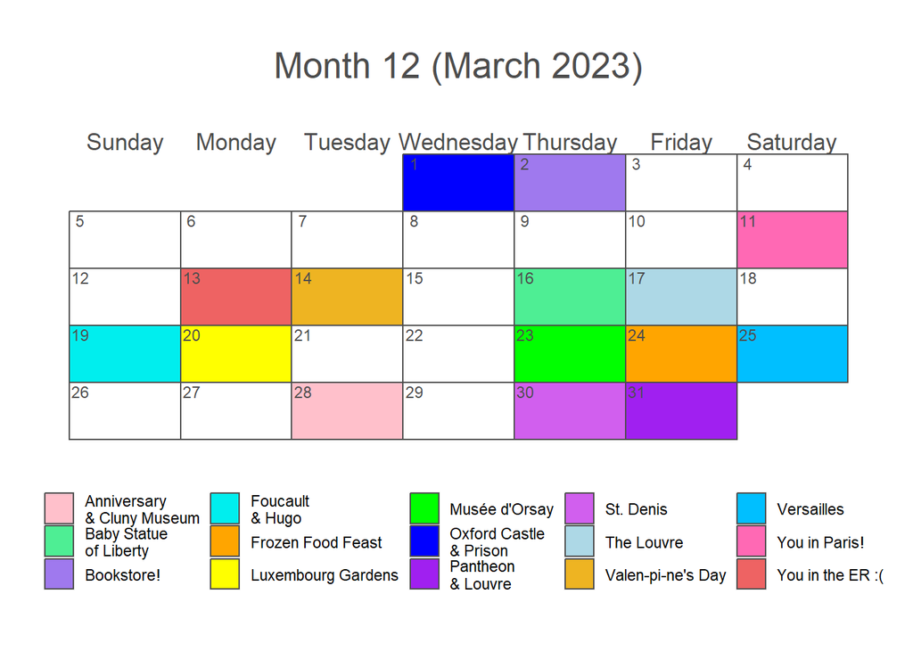

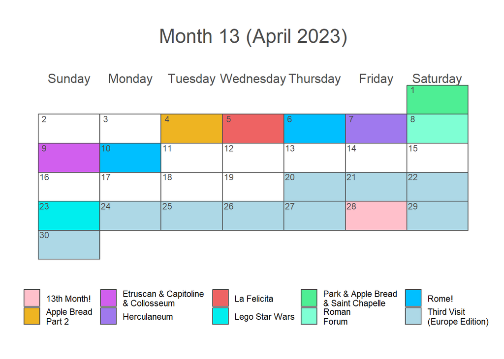

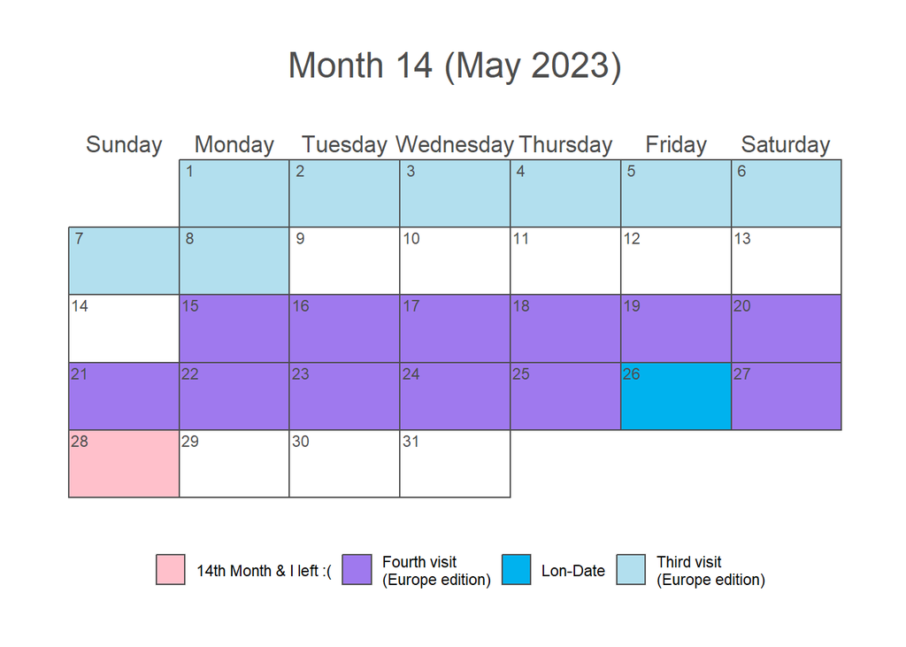

### Now

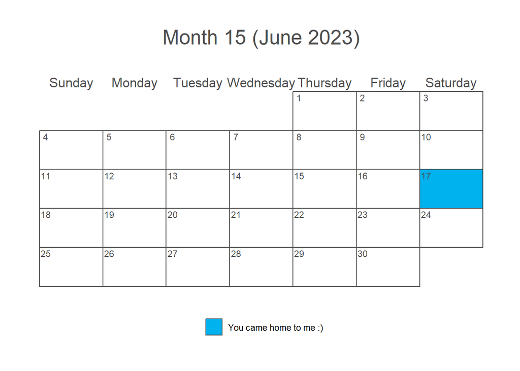

## Dates

Here are my thoughts on all the dates we’ve ever been on and how much I loved each of them! Also some bonus thoughts on how much I love you.

### The First Ten

Date 1: Daddy Issues Our first date! It’s wild to think about how long ago this was now. and how scared we were of getting caught when Allie was sitting right in front of us and Kat and Cameron were nearby but we held hands the whole time anyway. It was kinda silly that we tried to hide that under a jacket. I’m really glad you invited me to this because it was a super funny show and I had a great time watching it with you. It was also nice to eat pizza outside on a bench with you even though we ran into all of ADP at Mondo somehow. I still have “dinner with Elias :)” and “ice cream with Elias :)” in my calendar from that date. That was such a nice experience all around and a wonderful first date with you. I feel like it set the tone for how funny and wonderful and nice our relationship has been since then. I love you so much.

Date 2: WSA Debate Moderation

This was such a silly suggestion for a date but I think that’s what made it so fun, especially since our date ended up being published in The Argus then, so we were such a good couple as to even be newsworthy. I really enjoyed coming up with silly questions with you and dressing up and getting to sit with each other. It’s nice to be silly with you. It was also fun to be a bit serious and do a debate and then talk about how we felt about it (even though both of us forgot to actually vote in the end oops). I really like débriefing with you after we do stuff together. I always love hearing how you felt about stuff and seeing what we both liked and both disliked and where we differ too. I love your thoughts so much. And your silly jokes. You make me laugh so much.

Date 3: ER Trip

Thank you for thinking to make this a date to try and make things feel a lot less scary. It was kinda scary to go back to the ER, and I was worried about us after how bad this weekend was and the dumb stuff I did to get us into that place. It meant a lot to me that you still took me to the ER even though things were bad for you too. and that you did your best to spend time with me there even though I had to get a covid test and they kicked you out for that part. I’m sorry I have so many medical issues but thank you for always being so kind about them. You’re really good to me. Even so I hope we don’t have another ER date. I love spending time with you anywhere but maybe we should go somewhere else next time.

Date 4: Space Joe

My main memory from this is how incredibly freezing we were and how much we needed to cuddle for warmth when we got back to your room. As hellish as that was it was really nice to cuddle you and be so close to you like that. I really like being super close to you, even when it’s for sad reasons like being cold. And Joe is always a funny actor. I’m very glad that you started the trend of going to Joes for dates because I feel like those are always good. You always have such good date ideas. Thank you for being so thoughtful and so creative and for bringing to me to do such amaazing and fun things.

Date 5: Dr. Stranger

When I was talking about needing to go with someone to see this because I was scared of the horror tag the first time I brought up the movie, before we were even together, I was hoping you would be the one to come with me. And when it ended up being a bit spooky I was really happy you were there with me and you let me squeeze your hand and be close to you and feel protected. You’re my knight in shining armor :) And it was a good movie. I really like when we watch movies and tv shows together, whether it’s in the movie theatre or just at home in bed. It’s nice to be able to talk to you about them and cuddle you or hold hands or eat ice cream.

Date 6: ADP Reunion

This was such a fun time. I know it was a lot of work too and I’m sorry you had to do so much to set it up and I wish I could’ve helped more but I’m glad I was around to help as much as I could. I really loved meeting the alumni with you and showing them our date wall in our room. It gave me hope that we could be an alumni couple some day which I know is pretty intense for us having been together for only a few months but it somehow felt a lot longer than that at the time. Even now the idea of us having been together both feels impossibly long and yet too short to really capture how close we are. Being with you just feels right. And like it should be a part of my life, hopefully for a while. It was also really nice that you were able to stay on campus longer and we could spend more time together before we had to be apart for the summer. I’m sorry I interrupted that time because I had to go see my dad, but I was really glad that was quick and that I was able to come back.

Date 7: 2-Month Mondo

I think this was the first date I had the idea for, which is probably why it was kind of a boring one. I wanted to do something to celebrate us being together for 2 months which isn’t that long but I was happy about it anyway because I loved you (and still really love you) and like celebrating that you love me too. It was nice to eat pizza with you even though we ended up outside on the bench again. I don’t think we’ve ever actually had Mondo inside Mondo except during Anne’s party which is kinda weird to think about since we’ve gone a few times now. This is also the first date so far that I don’t have in my calendar which is kinda weird because I know we planned it out a bit and I remember having gone. I remember this being one of the last things we did together before we had to be long-distance, which is a bit of a sad association, but I’m really glad that we got to have one last date before the summer pulled us apart.

Date 8: Museum of Natural History

I loved looking at rocks with you :) And seeing the silly Easter island head from the Night at the Museum movie. And just exploring the museum with you. I’m sorry we had to pause for me to deal with Kyle being locked out of his room though. I wish I could’ve paid more attention to you the whole time because I love you and I love going places with you. I know you’ve been there a ton of times too, so thank you for still wanting to bring me to it and show me all the things you like about it. I was really glad that you shared it with me.

Date 9: 1 Gnocchi 4 2

Bella Luna! I remember the music there was kinda weird and I kept getting distracted by it. And how you felt weird about being college students who only bought one meal at the restaurant and how you thought they probably didn’t like us. We give them a good amount of business now though so I think they do like us probably. It was nice to eat out with you since we don’t do that a lot and it was kinda fun to be a bit spontaneous and get pasta randomly early before I had to take the train home. I really like doing things like that with you. Just deciding we want to do something and then doing it. It’s nice to plan things out too but theres something nice about liking each other enough to trust spontaneity.

Date 10: Train Surprises

Thank you for coming to meet me at Penn Station and bringing pasta. It was so nice to eat with you and steal some time together before I had to go to New Jersey. I missed you a lot that weekend and having any time with you always feels really important and good. Especially now that we’re long distance I appreciate time with you in a really different way. I thought it was basically going to be the same as the summer but this is a lot harder. I’m glad we were able to see each other so much over the summer even though we were in different places most of the time. And that we still get a lot of time together now despite everything. I really love you and I love spending time with you. I’m excited to keep adding more dates to this list with all of the cool stuff we do while we’re in Europe.

### 11-20

Date 11: Cone Sharing

Thank you for introducing me to new food. It always makes me really happy when I can share stuff with you, especially when it’s stuff you love. It was also really nice to see the ice cream shop that you went to as a kid and to have you teach me the dangerous life skill of eating ice cream from a cone without having it drip too much. I hope that we can share more ice cream cones again. Strawberry and chocolate ice cream go pretty well together which reminds me of us because we love those things and each other and we go pretty well together too :)

Date 12: Pancakes and Milkshakes

This was another one of those fun “yeah let’s do it!” moments. I was happy that I got to introduce you to something that I knew from Singapore, since I feel like those moments are pretty rare since Singapore is all the way on the other side of the planet. And that we got to share a crazy milkshake. And that I was able to make you pancakes and bring them to you to have lunch together when you were going to school. It was really nice to be your house boyfriend over the summer. I really like eating with you and cooking for you. And I was glad that you had some time to spend with me during lunch becasue I know that course was really really hard and I really appreciate that you made time to spend with me despite everything you had to do. I wish I could’ve been there more to take care of you, but I was glad I was able to make you lunch towards the end of it at least. This date was a bit earlier on though. It was when my train got delayed by two hours and it was late at night so I decided to say I was sick and not go to class and stay an extra day with you. I’m really glad that I was able to get so many surprise long weekends with you. Every extra day means the world to me.

Date 13: The Met Part 1

I was so excited to go to the Met with you. I really liked seeing turtle pond with you and walking thorugh Shakespeare’s garden and getting dressed up. I’m glad that you wanted to share the Met with me and you told me so much about all of the statues and that you were patient with me even though I had to keep sitting down on benches a lot. I hope it wasn’t too frustrating for you. You’re always so nice to me with things with my knee. I appreciate it a lot because I feel like it’s annoying or a burden for other people sometimes but you never make me feel like that. You always make me feel loved and wanted.

Date 14: Subway Exploration

Red mango! The financial district! The container store! This was so much fun :) Thank you for entertaining my silly idea of just travelling on the metro to random places. And for showing me red mango. They had such good frozen yogurt. The smoothie was so good too. I really understand why you liked it so much. I hope we can go back there together sometime over the summer when we’re back in the US. I hope we can have so many more smoothies together. Thank you for introducing me to so many amazing things like smoothies and the container store and so so many other places and foods and for being so patient with me and helping me try stuff. The world feels easier to navigate when we do it together.

Date 15: Date-tist

This was just silly. Still sad I didn’t get to meet your actual dentist. But it’s pretty amazing that you’ve got such good teeth. I’m proud of you for that :) Also, thank you for bringing me to things like your dentist appointments and other mundane parts of life. It makes me really happy that we get to be there for things like that for each other. Like we’re really connected. And we still have fun together even when we do things like bring you to the dentist. We must really love each other :)

Date 16: Hadestown

I know you’re not really a musical guy, so I was super surprised when you wanted to see Hadestown, for your birthday no less. It was really amazing to go to a fancy Broadway musical with you, and I was especially excited about you wanting to see it because it felt like a good way to combine our interests, even though it wasn’t really accurate to the original myth. Thank you for letting me rant about the technical aspects of the show too. I hope that you really did like coming to see this. I liked walking around and getting ice cream with you afterwards (twice! fancy rose and Ben & Jerry’s) and how we kept postponing returning home because it didn’t feel right to call it a night yet. Going out with you is really fun.

Date 17: Reading Together

I love reading with you. It’s really nice to do things separately but also be together. And talking to each other about what we’re reading and pointing out the silly parts to make each other laugh. I wish you were able to read a book you wanted to read and not a book for class, but hopefully we’ll read together again and then we can both read fun books and tell each other all about them.

Date 18: Town Exploration

This was a better idea in theory than in practice unfortunately :( I think it ended up going okay though in the end. I’m sorry it wasn’t better though. I wish we had been able to do all the stuff we planned on doing.

Date 19: Haicut x2

Thank you for showing me All People’s Barbershop. And for being so patient with me when I was too scared to go to a barbershop. And for still loving me when I cut my own hair and it looked horrible. You’re really sweet to me and so patient and so kind and so much more than I could’ve ever asked for. I’m so grateful that you’re a part of my life.

Date 20: Lovers Club Fair

I really like when you have date ideas like this. Where we do normal things like the WSA debate moderation or a club fair and just make them dates because why not. It’s really fun to go on so many dates with you that aren’t really conventional but feel wonderful because you’re there. It makes whatever we’re doing seem better. Being around you makes me so happy, no matter where we are or what we’re doing. And it’s fun to expand The Argus while also being in love :) I hope we get to do this again this year.

### 21-30

Date 21: Fake Fancy Gnocchi

I’m proud of the silly fake fancy set-up I had for this, even though it ended up not working how I imagined. It’s always nice to cook for you and eat with you. And it makes me really happy when you like the food I make. I want to eat pasta with you for a long time. I know this was not a Bella Luna date but it was gnocchi which reminds me of Bella Luna and makes me excited for us to have Bella Luna when we go back to the US. Which is today! Bella Luna day today :)

Date 22: Pasta Reunion

It was really nice to come back from Pace and eat pasta with vodka sauce with you. I missed you so much while I was gone and it was super sweet of you to go and get us pasta :) You’re so nice to me all the time. It’s also really nice to eat together in bed and then watch TV and eat ice cream and cuddle afterwards because the ice cream was too cold and now we’re shivering and need to warm up. I love having calm pyjama nights in with you. You make me so domestic and so happy. I love you.

Date 23: DnD Joe

Silly silly joe. Jow. Jhow? Did we ever figure out a spelling for that? Oh well. I liked seeing this with you. It was fun that it was interactive too, and that we got to joke around with the actors. They were really nice and fun. The cult part was silly too. I really like your jokes, and I was glad I got to hear a bunch when we were there in the beginning. I hope we get to watch a lot more Joes (Jows? Jhows?) together and laugh at his silly jokes. Joekes. Haha!

Date 24: Spooky Library

This was a really fun spookylibrary tour. It was also nice to be able to bring Talia along, even though that kinda ruins the date factor. It’s normally fun when the three of us hang out and it’s always good to get her out and interacting with people. It was also cool to learn more about the library and to get grilled cheeses together. Whey stationary is such a fun restaurant. Thank you for showing me that. And for inviting me to the see the spooky library tour. I liked the staircases that led nowhere.

Date 25: Gay Greeks

I can’t believe how packed this talk was. It was interesting for me to be at though, and I’m really glad that you wanted me to come with you. I like learning about the things you like, and hearing your thoughts about things you’ve learnt that I’ve seen too. It’s always really cool for me to get the perspective of whoever is talking and then your perspective on the same topic because I feel like you know so much about so many things and always have cool thoughts to add. I love your brain.

Date 26: Masquerade

This was a terrible idea. I’m glad you still love me after I suggested we go watch this awful awful show. I feel very lucky. It was just so bad. But it was incredibly fun to rant about how bad it was with you afterwards too. I love when we share frustrations and just keep ranting to each other which makes the rant continue on and get stronger and we have similar opinions and just get to vent our feelings about how horrible something is. The moreI get to know you the more I understand the things that really get to you and why, I love learning more about how your brain works. I really love doing everything with you.

Date 27: COL Formal

This was such a wild event. Sometimes I still wonder about if we actually set off that alarm by exploring the building. Russell House is a really weird place, and it was fun to wander around it with you. And to meet your COL classmates. I can’t wait to go again with you this year :)

Date 28: Painting Show

Thank you for coming to this with me even though you had a ton to do for astronomy and your huge final project. It was really nice to see you for a bit and share a smoothie. I like looking at art with you. It doesn’t feel nearly as interesting when I’m looking at it on my own.

Date 29: Library Day/Visa Appointment

I’m sorry I was so stressed for most of this date, but thank you for letting me use your library card to print and for introducing me to the cool NYPL system! The libraries are so big. I still think about how the librarian thought we were both under 18 sometimes because it’s both funny and painful. Thank you for coming with me to the visa appointment as well. I’m sorry you had to wait outside though. You’re always really nice to me. I hope that I can help you as much as you help me.

Date 30: Bookstore (Barnes & Noble Edition)

I’m glad we’ve had so many book related dates. It’s really fun to look at books with you and talk about them. I don’t really recommend books to anyone and it’s nice that you listen to me talk about all of them and sometimes spoil them if you think you probably won’t read them. It makes me happy when you seem interested in book plots that I’ve really liked too. You’re really sweet for listening to me poorly explain their plots. I really like hearing about the books you’ve read too, especially since they’re so different from what I normally read. I hope that someday I can read all of the books you’ve told me about because they all sound really cool and I think you have really good taste in books and I’d love to see why you enjoy the books you enjoy.

### 31-40

Date 31: The Met Part 2

Thank you for pushing me around in the wheelchair, and for coming with me to some of the weirder exhibits like the musical instruments part. I hope it wasn’t boring for you to see those things, since I know you’ve been to the Met a lot. I really like going to museums, and specifically the Met, with you thought. I love seeing how excited you get, and learning about so many interesting things with you. It was also nice to be able to try out using a wheelchair with you because sometimes walking around is really hard and I want to be able to spend a lot of time with you in places that you really like. I’m sorry that it got hard to push me around though. I’m always happy to wheel myself too so please don’t feel like you have to. Thank you for helping me with it anyway. I liked seeing the little house part of the museum too, and it was fun that there was an accessible portion there. Thank you for taking me to see so many of the things you think are cool. I think they’re pretty cool too, but that you’re the coolest of all.

Date 32: Little Lego Guys

It was so fun searching for tiny versions of us with you and struggling to find the perfect clothes and hair (and failing and finding the best available ones). I’m always really happy when I look over at mny desk and the lego version of you is sitting there. It feels like you can’t really be that far away.

Date 33: Plane Date

It was so sad when you had to leave in the airport, but I’m glad we got to have one last date in the US before we left. I liked sharing milkshakes and fries with you at Shake Shack, and walking around and looking at all the random airport things. I’m really glad you were able to get your wallet before we left though that was spooky. I’m also glad I was able to be there with you in the airport and you were there with me because being together is always really nice and airports are spooky and sad alone.

Date 34: Pizza Abroad

I was really happy when we did this. It felt amazing to be able to find little things we could do together that made us feel less far apart. Eating different pizzas in different places at the same time was really nice. And pizza is really good so that probaby added to my happiness a bit too. I find a lot of comfort in doing things like eating at the same time or going to bed at the same time so I’m super glad we were able to start doing that with a few things sometimes. I hope it brings you comfort and makes me feel less far away too. The distance is really sad sometimes.

Date 35: No Man’s Sky

I love that I get to see your avatar and give you little space kisses and explore your bases and we can show each other all the cool stuff we’ve found but do our own things too. Playing No Man’s Sky with you is super fun and I’m sorry that it gets really frustrating sometimes and crashes a lot when we play multiplayer and doesn’t work sometimes but I hope that it’s still fun for you despite those issues. If it’s not we don’t have to play it but I really like having something to do with you where I can pretend I’m looking at you.

Date 36: No Man’s Sky the Sequel

Boyfriend game! Thank you so much for getting this game for me before we left. I really love it. Not as much as I love you, of course.

Date 37: Classics Day!

The Ashmolean museum is no Met, but I still really liked it. It’s always fun for me to go to classics related things with you because I’ll learn so much about the stuff you know about. It makes me never want to do my own research about it because I like hearing about how you explain it (and sometimes people believe in evil and wrong things and I don’t want to accidentally do that so I’m very glad that you are kind enough to tell about which things are super duper wrong so that I don’t fall into that trap).

Date 38: Libraries/Bookstore (Waterstones Edition)

I’m sorry I was too tired to really go into the libraries, but they all looked really cool and thank you for showing me them and bringing me to look at the buildings and going to the bookstore with me and showing me cool books and buying me Orlando. I’m really happy that you share the books you like with me. Reading them feels like I get to see a piece of you.

Date 39: LMH Day

Thank you for taking me to see the library and resting with me. It’s always really nice to cuddle you. I’m sorry I push you out of the bed there sometimes though. I promise I don’t mean to. If anything I would want to pull you onto me. Nonetheless, I really like staying in with you and cuddling. And feel free to give me a bit of a shove if I take up too much space.

Date 40: No Man’s Sky the Threequel

It’s silly that we counted so many of these as dates we would’ve had so so many dates in the early study abroad months if we kept doing that. But maybe that would make everything else feel less special, so it’s probably better that we stopped counting them as dates in the end. I hope we will have time to play video games together again.

### 41-50

Date 41: Queer Oxford and Brownie Sundae

I was really surprised by how many people went to the Queer Oxford museum night. And also how weird the music was. And how many people were listening to it and seemed super into it. I know the museum was a bit boring but I liked wearing silly hats with you and playing the typhoidland games, even if they were super easy. I hope that you still had fun even though it wasn’t a great museum. I had fun because I was with you. I’m sorry I was so tired though. Thank you for taking me to get a hot chocolate and a brownie sundae afterwards. It was funky how their microwave didn’t work and the guy super burnt the brownie before we got a proper one. I really liked the hot chocolate and the brownie sundae though, and it was nice to sit and just enjoying eating ice cream with you. I love when we do casual fun things like that together. I hope we get to have lots more ice cream together.

Date 42: Oxford Castle & Prison

This was much more fun than I was expected! I like castles and you like castles so I figured it would be cool even if the tour was bad but Emily was silly and funny and the castle had funky prison stories and I liked getting our mugshots taken and then stealing pictures of them (get it that’s ironic because stealing is a crime). I still think about how whacky those stairs were though. I’m glad that neither of us fell down them because they were such a trick and so small and dizzying and I hope we do not encounter other stairs like that during our normal lives.

Date 43: Bookstore Part 2 (Waterstones Edition)

I’m sorry you were so tired for this and your phone was not with us that was spooky and I’m sure made it hard for you to have a lot of fun on this date but I hope that you enjoy the book. I’m happy that so many of our dates have been to bookstores, especially Waterstones, because it’s one of my favorites and I’m really glad to share it with you.

Date 44: Valen-pi-ne’s day

It was nice to walk the talk and eat pasta with you and celebrate a second Valentine’s day with you :). I was glad that we were able to find time to make up Valentine’s day twice since it was sad that we missed it this first time. I hope that we’ll be able to celebrate it on the 14th next year! It was fun to try the chocolates from the chocolate box with you again too, especially since we were attempting to remember what was in them. I also enjoyed hearing your commentary on the talk and the stories she was talking about. I always really love learning stuff from you, especially when it relates to other stuff we’ve done together like watch Thor movies which are silly and fun.

Date 45: Baby Statue of Liberty

I can’t believe there are so many statute of liberties in France. It’s so wild that America just kept giving them back to France, and it’s really funny that this is right by your Airbnb. Thank you for telling me about this and taking me on a walk to go see it. I know it was hard for you here the first week because France is evil and made you sick but I’m glad we still got to do so much together and spend more time together because of my classes being cancelled. It’s also really nice to go on walks with you here. It makes me wish I could see more of Paris on my feet.

Date 46: The Louvre

I’m glad we went to the Louvre together. Thank you for pushing me around this museum even though it was confusing and huge and crowded and we got lost so many times. I’m sorry it was so exhausting but I’m glad I got to buy you crepes afterwards. It was wild how we accidentally got caught up in strike closures while on the metro though. France was a really strange place to live when we were both there, but I’m glad you were there with me for a part of it. It didn’t feel as overwheleming when I knew we would go through it together.

Date 47: Foucault’s Pendulum and Victor Hugo’s House

This was such a cool museum. Thank you for showing it to me. This was my favorite museum that we went to out of all of the ones we went to in Europe together. I loved seeing the little robots and the building models and the pendulum. You always have such good ideas of places to go :) Thank you for taking pictures of things for me and coming back to show them to me when I was struggling.

Date 48: Luxembourg Gardens

Thank you for coming to see this with me as a date even though technically I went for class assignments. I had wanted to go and look at it since I had been going to class right next to it but didn’t want to go alone. I’m glad we shared a baguette and looked at the statues together and held hands. It was a really nice moment and I really appreciate that you came all the way there to see me during the school day. I really love spending time with you however we can. Date 49: Musée d’Orsay

This was my favorite museum in Paris, besides the Arts and Materials one, which was definitely the coolest museum we’ve been to together. I really liked all of cool statues and paintings that we saw and the fact that it was in a train station!! I also was very happy to be able to show you the big train I really liked taking. I really like going to museums with you. I’m sorry you always push me around at them though because I’m sure that’s really tiring and I owe you dinner after museum dates forever now.

Date 50: Frozen Food Feast

It’s so cute much you loved Picard. I enjoyed that we were able to have fun frozen food and make things fake fancy even though we had such a tiny kitchen. It was really fun making everything and then cuddling up to eat it together. I’m glad we also did that when I came to see you at Oxford. I hope it becomes a tradition for us to make fun frozen food every now and then :)

### 51-60

Date 51: Château de Versailles

The petit train! It was so small and cute :) And the gardens were so pretty and cool even though it was cool (literally) and windy and hard to be outside a bit. I liked discovering that you like hot chocolate, but only the kinds I don’t like as much, which is another way we balance each other out! I also always enjoy taking the big train so it made me happy that we were able to take it together. I was happy that we got to lose the group pretty easily and just hang out with each other because I really wanted to spend time with you and make it a proper date.

Date 52: Anniversary Cluny Museum

I’m really glad that there was a strike on our anniversary and I didn’t end up having to go to class and that we were able to go to Cluny instead and see a bunch of cool stuff together. I thought it was cute how defensive you were of the art and statutes in the museum since you said sometimes people think they’re simplistic or boring but you love them. I love how passionate you are about all the museums you want to go to with me :)

Date 53: Basilique de Saint Denis

This was such a cool church. I still think about how the light was reflecting off the windows and onto the floor and the pews and the walls and how it was so pretty and colorful. I really liked seeing this with you. It was such a cool building and it’s really fun for me to see all the architectural stuff that you always tell me about. It was nice to see a pretty place like this with you, my pretty pretty boyfriend :)

Date 54: Pantheon + Louvre

Thank you for pushing me around this museum again. I know it’s really exhausting and hard, but it’s really sweet of you to always do it anyway. I liked how we got to see different parts of the Louvre. I’m sorry that the vase section was still closed off :( I was really excited for you to be able to see them after you loved your class on it so much. I’m also sorry for crying in the Pantheon and getting frustrated and for it being disappointing even though it was expensive. Thank you for being nice to me about it all anyway.

Date 55: Park + Apple Bread + Saint Chapelle

I know you hated this church, but it was fun to go to apple bread with you. I liked showing you my favorite sandwich restaurant in Paris because you love sandwiches so much and I wanted you to get to have some good ones while you were there with me. I’m glad that you liked it too. I’m sorry that this date was so impromptu and we never found the train tracks in the park. That was a really good idea you had and I would’ve loved to see them with you. I hope we go to the NYC version you told me about some day. It’s really cute how you try to find things I’ll like when we go places. It makes me feel looked out for, and I hope you feel looked out for too. I’m sorry you’re mostly the one coming up with ideas. I hope that some of the stuff I’ve shown you has been good.

Date 56: Apple Bread Part 2

Thank you for coming to visit me at school for our last week in Paris (twice!). It was really nice to have lunch with you. I’m sorry my school days were so incredibly long and I couldn’t really get home easily. I like eating with you and sharing food a lot, so it meant a lot to me that you would come all the way down to where I was just so we could eat together. I hope it wasn’t too awkward that my professor also eats there randomly.

Date 57: La Felicita

You had lunch with me at school again :o And let me eat most of your fries! You are way too nice to me most of the time. I want to give you more of my food in return. We should always be sharing. I hope you liked this place, even though they didn’t really have any pasta you wanted. I know that was kinda disappointing and I’m sorry. You love pasta.

Date 58: Herculaneum

This is probably one of my favorite dates, just because of how excited you were the whole time. It’s really adorable watching you get super into a place we’re visiting and start telling me a bunch of information about it :) I love learning about the stuff you love, so thank you for always sharing it with me. Even though the train ride was really long and it was hot and so much walking, it was really fun to get gnocchi and ice cream with you (so much ice cream!). The flavour you picked at the train station gelato place was really good. I’m glad that you’re helping me find new food I like, and always sharing it with me. I like learning that there are lots of things I like, way more than I expected, and that you like them too so we can have them together :) I know you’re not a big fan of day trips, but I think this one was a good one.

Date 59: Roman Forum

This was so big and so much walking. That’s the main thing I remember. But the buildings were pretty cool and there was a lot to see. I know it wasn’t your favorite, but it was still cool that we got to go the museum and stuff. I’m sorry I was really upset in the museum. I don’t even remember why I was crying now, but I remember doing it, which I’m sorry for because I didn’t want to ruin the museum trip for you. It’s always fun to see statues and stuff together. I’m sorry my knees make it hard for me to keep up with you during things like this and the Herculaneum. I hope that it’ll be easier after I get surgery and we can do more stuff together.

Date 60: Etruscan + Capitoline + Collosseum

I remember doing a lot of walking for this date too, and being forced to sit down a couple times since it was such a long day. Rome really was a ton of walking. I hope that the next time we do that much walking I have working knees. The Etruscan museum was really fun, even though the staff were a bit silly and overly nice about everything and also didn’t speak English. I liked that there was so much we could see, and how happy it made you to see all of it. It was also really good that we were away from the crowds. I hope that helped you relax a bit more. I’m sorry Rome was so crowded all the time and getting tickets for stuff was so incredibly difficult. I hope you still enjoyed it. I enjoyed being there with you, and especially eating all of the gnocchi that we had. I can’t believe the final gnocchi date we had before we went to drop me off at the train station wasn’t recorded as a date :( I must have forgotten to ask if it was one in the midst of all the being sad. But going to that restaurant and eating that gnocchi was incredible, and it would be a shame to leave something that good off this list of cool things we did together while traveling.

### 61-Present

Date 61: Lego Star Wars

Thank you for playing this game with me so many times. I can tell it’s not really your favorite, and it’s okay if you’re a bit tired of it, but I appreciate that you played with me because I like it even if you don’t really. I like playing video games with you a lot. I hope we can find some more that you like too so we can keep playing new games together.

Date 62: Pizza Express + the Owl House

I’m glad that you liked this show :) I really liked watching the Owl House the first time I saw it, and I really wanted to share it with you because it was good and fun and gay and that’s just like us! It was really nice to watch it again while cuddling you and eating pizza together. You’re also really cute and silly for always giving me extra dough balls because you know I like them so much. Thank you for getting Pizza Express so many times while I was in Oxford even though it’s a bit expensive to do that often. I hope we can get Bella Luna again together a few times once you’re back in NYC. I like our dinner + movie/TV show dates a lot. Hopefully we can do a better job at coming up with stuff to watch, but it’s a bit hard now that we’ve sort of exhausted both of our lists.

Date 63: Lon-Date

I enjoyed going to the bank museum with you :) It was fun to get to see the history of the bank and do puzzles together and try to control inflation. It was a really nice museum, and I’m glad that we went to London even if the rest of the trip was disappointing. I’m sorry about how much the British Museum sucked. I was really excited to see more cool Greek and Roman art with you but British people :( I hope you don’t regret going. I’m also sorry about how much the bus ride sucked, but I’m glad that we were together for it. I hope you’ll lean on my shoulder many many more times and we have lots more chances to be so so sleepy, but preferably in a bed.

Bonus Note

Writing all of these out and making the calendars and the graphs and the maps was a really nice way to look back on our relationship and realize how much I really enjoy doing stuff with you. Whether it’s sitting in bed watching TV or playing video games, travelling even though it makes us tired and grumpy, exploring a museum, watching a Jow, or anything else we do together, I always love being with you. Even if we’re tired or sad or it doesn’t go as expected, it’s nice to make memories with you and have things we can look back on and complain about together. I hope that we get to go on many many more dates. I love you so much. I hope that you liked our dates as much as I did.

## Graphs

### Dates by Location/Month

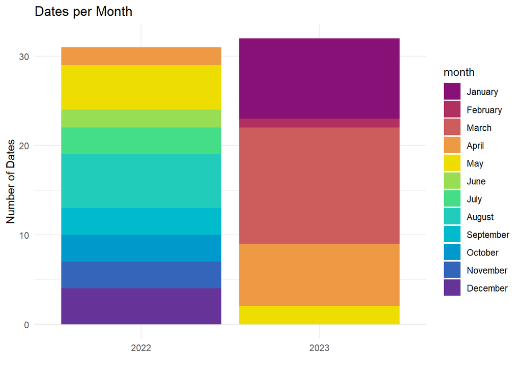

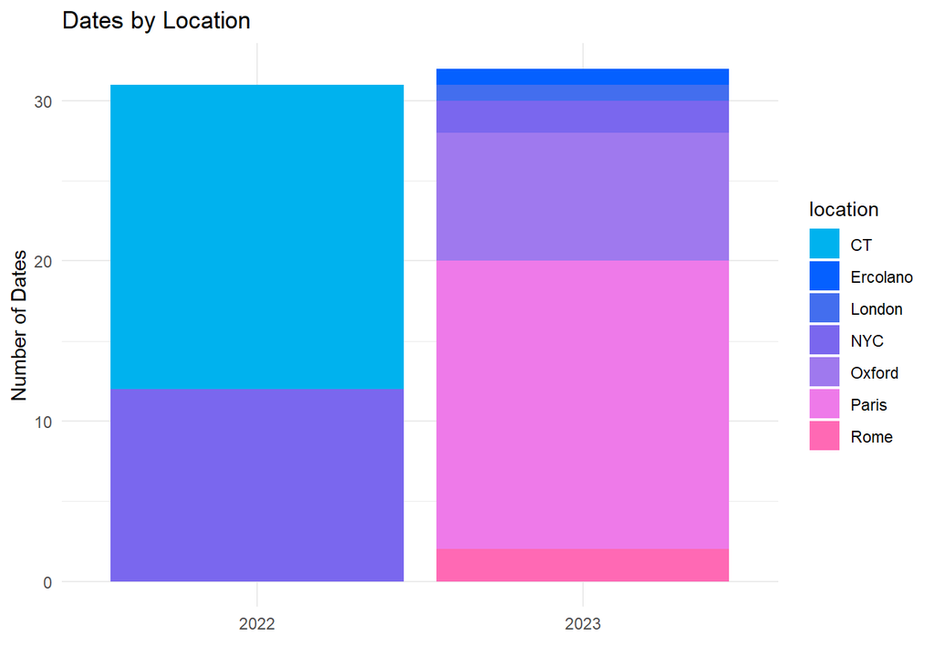

### Date Scores

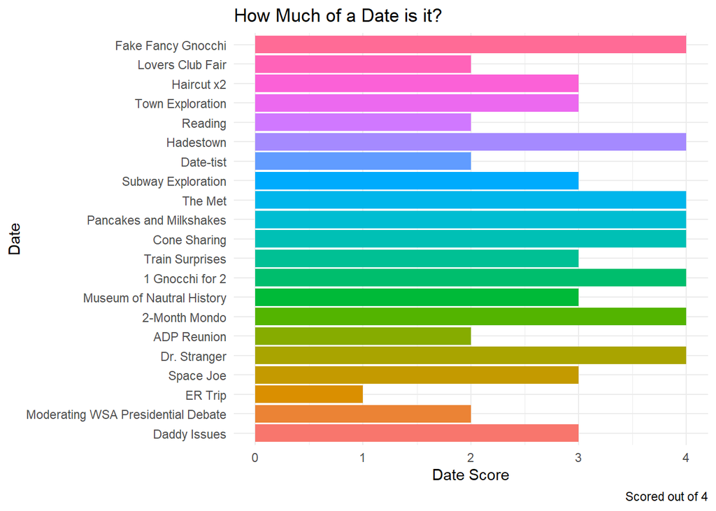

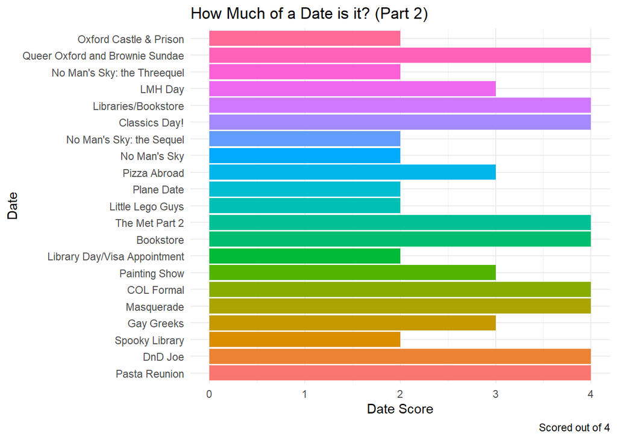

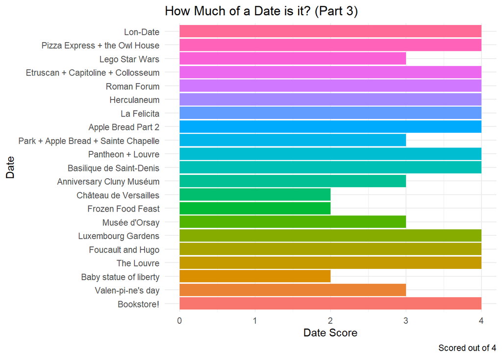

## Maps

### Connecticut

[interactive chart not shown]

### NYC

[interactive chart not shown]

### Paris

[interactive chart not shown]

### Oxford/London

[interactive chart not shown]

### Italy

[interactive chart not shown]